# IS624 Week 6

Aaron Palumbo

Tuesday, July 14, 2015

HA - 8.1, 8.2, 8.6, 8.8

```r
library(knitr)
library(fpp)

# Suppress messages and warnings in all chuncks
opts_chunk$set(message=FALSE, warning=FALSE)
```

## 8.1

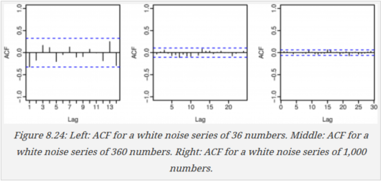

**Figure 8.24 shows the ACFs for 36 random numbers, 360 random numbers and for 1,000 random numbers.**

### 8.1 (a)

**Explain the differences among these figures. Do they all indicate the data are white noise?**

These figures show the correlation between different lags of the series (shown on the x axis). The y axis (the correlation) has the same scale for each plot, but the x axis shows an increasing number of lags as the series gets longer.

If the data are white noise (random) then we expect the correlations to be below the blue line, which indicates a significant lag.

For all the plots, the correlations of the lags shown are all below the significance level so they are all indicitive of white noise.

### 8.1 (b)

**Why are the critical values at different distances from themean of zero?**

The value of a significant correlation ($k$) is determined by the following equation: $k = [(T - 1)^{1/3}]$ where T is the number of data. From this we can see that as the number of data increase value of a significant correlation decreases.

## 8.6

### 8.6 (a)

**By studying appropriate graphs of the series in R, find an appropriate ARIMA($\mathbf{p, d, q}$) model for these data.**